# HW 03

## 3 - COVID survey - reconstruct

```r
covid <- read.csv(here("data", "covid-survey.csv"), skip = 1)
dim(covid)
```

```
[1] 1121   14
```

```r
#cleans the row names
covid <- clean_names(covid)
covid <- covid |>
  #filters out the first row so that the second row can be the names of the col
  filter(if_any(-1, ~ !is.na(.))) #*
dim(covid)
```

```
[1] 1111   14
```

- *Code after consulting with https://www.tidyverse.org/blog/2021/02/dplyr-1-0-4-if-any/. -1 from my own code, ‘~ !is.na(.)’ formatting consulted from AI after multiple bug issues.

```r
covid_survey <- covid |>

  #changes all the col values in accordance with directions
  mutate(
    "exp_already_vax" = if_else(exp_already_vax == 0, "No", "Yes"),

    "exp_flu_vax" = if_else(exp_flu_vax == 0, "No", "Yes"),

    "exp_profession" = if_else(exp_profession == 0, "Medical", "Nursing"),

    "exp_gender" = case_when(
      exp_gender == 0 ~ "Male",
      exp_gender == 1 ~ "Female",
      exp_gender == 3 ~ "Non-binary third gender",
      exp_gender == 4 ~ "Prefer not to say",
    ),

    "exp_race" = case_when(
      exp_race == 1 ~ "American Indian/Alaskan Native",
      exp_race == 2 ~ "Asian",
      exp_race == 3 ~ "Black/African American",
      exp_race == 4 ~ "Native Hawaiian/Other Pacific Islander",
      exp_race == 5 ~ "White"
    ),

    "exp_ethnicity" = if_else(exp_ethnicity == 1, "Hispanic/Latino", "Non-Hispanic/Non-Latino"),

    #age changed to factor so it can be easily ordered.
    "exp_age_bin" = factor(case_when(
      exp_age_bin == 0 ~ "<20",
      exp_age_bin == 20 ~ "21-25",
      exp_age_bin == 25 ~ "26-30",
      exp_age_bin == 30 ~ ">30"),

      levels = c("<20", "21-25", "26-30", ">30")), #*

    #response changed to double to appear close to reference dataframe
    "response_id" = as.double(response_id)
  )

dim(covid_survey)
```

```
[1] 1111   14
```

- *http://www.cookbook-r.com/Manipulating_data/Changing_the_order_of_levels_of_a_factor/

```r
#creates a new column with the pivoted explanatory values. The row titles goes in explanatory, the row values go in explanatory values.
covid_survey_longer <- covid_survey |>
  pivot_longer(
    cols = starts_with("exp_"),
    names_to = "explanatory",
    values_to = "explanatory_value"
  ) |>

  #filters out NA values
  filter(!is.na(explanatory_value)) |>

  #creates a new column with all the response values. The row titles go in reponse, the values in response values.
  pivot_longer(
    cols = starts_with("resp_"),
    names_to = "response",
    values_to = "response_value"
  )
glimpse(covid_survey_longer)
```

```
Rows: 43,428
Columns: 5
$ response_id       <dbl> 1, 1, 1, 1, 1, 1, 1, 1, 1, 1, 1, 1, 1…
$ explanatory       <chr> "exp_profession", "exp_profession", "…
$ explanatory_value <chr> "Nursing", "Nursing", "Nursing", "Nur…
$ response          <chr> "resp_safety", "resp_confidence_scien…
$ response_value    <int> 5, 2, 2, 1, 1, 1, 5, 2, 2, 1, 1, 1, 5…
```

The first pivot longer is taking all the explanatory values (ie background info) and putting it in explanatory_value while the second pivot longer is taking all the response and putting them under response_value.

```r
#creates a tibble that has the mean, 10 quantile, and 90 quantile for each group and response.
covid_survey_summary_stats_by_group <- covid_survey_longer |>
  group_by(explanatory, explanatory_value, response) |>
  summarise(mean = mean(response_value, na.rm = TRUE),
            low = quantile(response_value, probs = 0.1, na.rm = TRUE), #*
            high = quantile(response_value, probs = 0.9, na.rm = TRUE))

#reorders the group so that it can be graphed nicely
covid_survey_summary_stats_by_group <- covid_survey_summary_stats_by_group[order(covid_survey_summary_stats_by_group$explanatory_value),] #**

glimpse(covid_survey_summary_stats_by_group)
```

```
Rows: 126
Columns: 6
Groups: explanatory, explanatory_value [21]
$ explanatory       <chr> "exp_age_bin", "exp_age_bin", "exp_ag…
$ explanatory_value <chr> "<20", "<20", "<20", "<20", "<20", "<…
$ response          <chr> "resp_concern_safety", "resp_confiden…
$ mean              <dbl> 3.352941, 1.647059, 1.705882, 1.41176…
$ low               <dbl> 2, 1, 1, 1, 1, 1, 1, 1, 1, 1, 1, 1, 2…
$ high              <dbl> 4.4, 2.4, 3.8, 2.0, 2.0, 1.8, 5.0, 3.…
```

*https://www.tidyverse.org/blog/2020/03/dplyr-1-0-0-summarise/ **https://bookdown.org/ndphillips/YaRrr/order-sorting-data.html

```r
#creates the mean, 10 quantile, 90 quantile, explanatory and explanatory placement values for all of the data
covid_survey_summary_stats_all <- covid_survey_longer |>
  group_by(response, .drop = FALSE) |>
  summarise(mean = mean(response_value, na.rm = TRUE),
            low = quantile(response_value, probs = 0.1, na.rm = TRUE),
            high = quantile(response_value, probs = 0.9, na.rm = TRUE),
            explanatory = "ALL", #code inspired from discussion in HW channel
            explanatory_value = factor(""),
            .groups = "drop"
            )

covid_survey_summary_stats_all
```

```
# A tibble: 6 × 6
  response         mean   low  high explanatory explanatory_value
  <chr>           <dbl> <dbl> <dbl> <chr>       <fct>
1 resp_concern_s…  3.28     1     5 ALL         ""
2 resp_confidenc…  1.43     1     2 ALL         ""
3 resp_feel_safe…  1.36     1     2 ALL         ""
4 resp_safety      2.03     1     5 ALL         ""
5 resp_trust_info  1.40     1     2 ALL         ""
6 resp_will_reco…  1.21     1     2 ALL         ""
```

```r
#puts the two dataframes together
covid_survey_summary_stats <- rbind(covid_survey_summary_stats_all, covid_survey_summary_stats_by_group) #*

covid_survey_summary_stats
```

```
# A tibble: 132 × 6
   response        mean   low  high explanatory explanatory_value
   <chr>          <dbl> <dbl> <dbl> <chr>       <fct>
 1 resp_concern_…  3.28     1   5   ALL         ""
 2 resp_confiden…  1.43     1   2   ALL         ""
 3 resp_feel_saf…  1.36     1   2   ALL         ""
 4 resp_safety     2.03     1   5   ALL         ""
 5 resp_trust_in…  1.40     1   2   ALL         ""
 6 resp_will_rec…  1.21     1   2   ALL         ""
 7 resp_concern_…  3.35     2   4.4 exp_age_bin "<20"
 8 resp_confiden…  1.65     1   2.4 exp_age_bin "<20"
 9 resp_feel_saf…  1.71     1   3.8 exp_age_bin "<20"
10 resp_safety     1.41     1   2   exp_age_bin "<20"
# ℹ 122 more rows
```

*https://www.datacamp.com/doc/r/merging

```r
#reordering explanatory so that it can be better graphed in order
covid_survey_summary_stats$explanatory <- factor(covid_survey_summary_stats$explanatory,
      levels = c("ALL", "exp_age_bin", "exp_gender", "exp_race", "exp_ethnicity", "exp_profession", "exp_already_vax", "exp_flu_vax"))

#to be labeled on the graph
questions <- c("resp_safety" = "Based on my understanding, I believe the vaccine is safe",
               "resp_feel_safe_at_work" = "Getting the vaccine will make me feel safer at work",
               "resp_concern_safety" = "I am concerned about the safety and side effects of the vaccine",
               "resp_confidence_science" = "I am confident in the scientific vetting process for the new COVID vaccines",
               "resp_trust_info" = "I trust the information that I have recieved about the vaccine",
               "resp_will_recommend" = "I will recommend the vaccine to family, friends, and community members")

#to be labeled on the graph
id_info <- c("ALL" = "All",
             "exp_age_bin" = "Age",
             "exp_gender" = "Gender",
             "exp_race" = "Race",
             "exp_ethnicity" = "Ethnicity",
             "exp_profession" = "Profession",
             "exp_already_vax" = "Had COVID vaccine",
             "exp_flu_vax" = "Had flu vaccine this year")
```

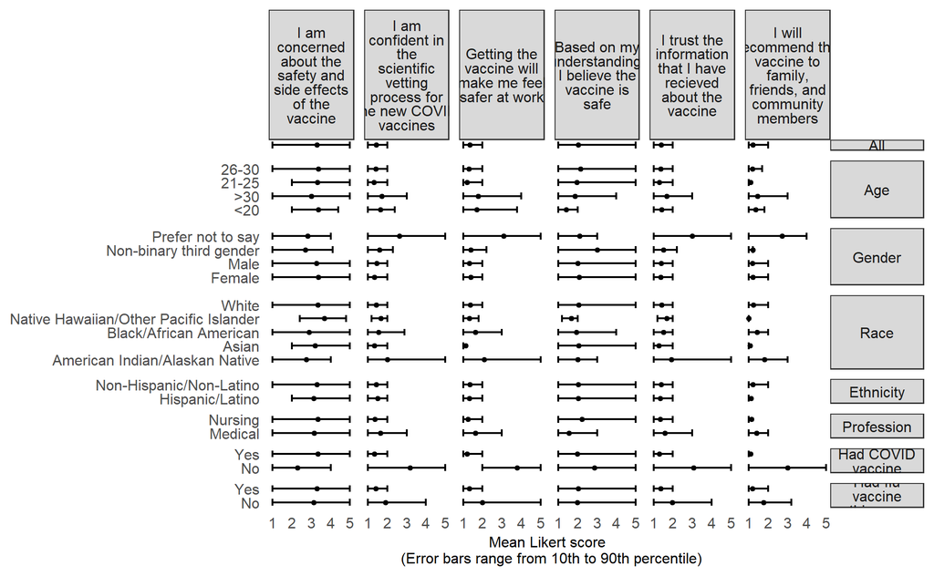

```r
covid_survey_summary_stats |>
  #maps mean to explanatory value
  ggplot(aes(x = mean, y = explanatory_value)) +

  #creates the error bars for each point with the ends at the 10 and 90 quartile
  geom_errorbar(aes(xmin = low, xmax = high), width = 0.5) + #from documentation

  #creates the datapoint for each response
  geom_point(size = 1) +

  #facets based on reponse and explanatory
  facet_grid(cols = vars(response),
             rows = vars(explanatory),

             #"free_y" allows for the explanatory values on Y to be for the whole graph and not smushed in the facet of explanatory
             scales = "free_y",
             space = "free_y",

             #takes the labels created above and maps them to each of the variables
             labeller = labeller(explanatory = as_labeller(id_info, default = label_wrap_gen(width = 10)),
                                 response = as_labeller(questions, default = label_wrap_gen(width = 14))
                                 )) +
  labs(
    x = "Mean Likert score \n (Error bars range from 10th to 90th percentile)",
    y = NULL
  ) +

  #attempt to better space out the y axis but not quite there
  scale_y_discrete(expand = c(0.1, 0.3)) + #*

  #theme with the grey boxes for facets
  theme_bw() +

  #changes the texts size and gets rid of all the grid elements
  theme(
    strip.text.x = element_text(size = 8, lineheight = 0.8),
    strip.text.y = element_text(size = 8, lineheight = 0.8, angle = 0),
    panel.grid = element_blank(),
    panel.border = element_blank(),
    axis.ticks = element_blank(),
    axis.title.x = element_text(size = 8),
    axis.text.y = element_text(size = 8),
    axis.text.x = element_text(size = 8)
  )
```

- *https://stackoverflow.com/questions/15400486/change-distance-between-x-axis-ticks-in-ggplot2

## 4 - COVID survey - re-reconstruct

```r
#only change is that the low and high values are the 25 and 75th quantile respectively
covid_survey_summary_stats_by_group2 <- covid_survey_longer |>
  group_by(explanatory, explanatory_value, response) |>
  summarise(mean = mean(response_value, na.rm = TRUE),
            low = quantile(response_value, probs = 0.25, na.rm = TRUE),
            high = quantile(response_value, probs = 0.75, na.rm = TRUE))

covid_survey_summary_stats_by_group2 <- covid_survey_summary_stats_by_group2[order(covid_survey_summary_stats_by_group2$explanatory_value),]

covid_survey_summary_stats_all2 <- covid_survey_longer |>
  group_by(response, .drop = FALSE) |>
  summarise(mean = mean(response_value, na.rm = TRUE),
            low = quantile(response_value, probs = 0.25, na.rm = TRUE),
            high = quantile(response_value, probs = 0.75, na.rm = TRUE),
            explanatory = "ALL",
            explanatory_value = factor(""),
            .groups = "drop"
            )

covid_survey_summary_stats2 <- rbind(covid_survey_summary_stats_all2, covid_survey_summary_stats_by_group2)

covid_survey_summary_stats2$explanatory <- factor(covid_survey_summary_stats2$explanatory,
      levels = c("ALL", "exp_age_bin", "exp_gender", "exp_race", "exp_ethnicity", "exp_profession", "exp_already_vax", "exp_flu_vax"))
```

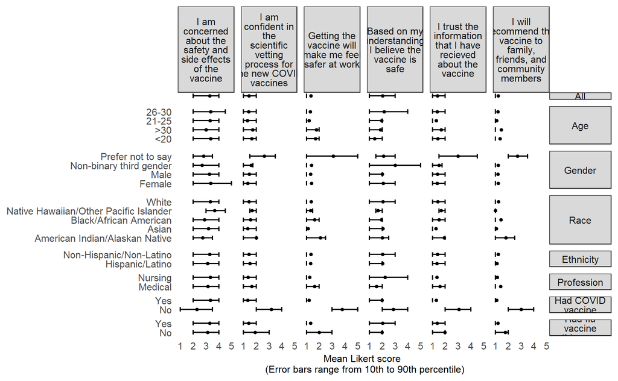

```r
#same code as above but with the new dataframe with the 25th and 75th quantile values

covid_survey_summary_stats2 |>
  ggplot(aes(x = mean, y = explanatory_value)) +
  geom_errorbar(aes(xmin = low, xmax = high), width = 0.5) + #from documentation
  geom_point(size = 1) +
  facet_grid(cols = vars(response),
             rows = vars(explanatory),
             scales = "free_y",
             space = "free_y",
             labeller = labeller(explanatory = as_labeller(id_info, default = label_wrap_gen(width = 10)),
                                 response = as_labeller(questions, default = label_wrap_gen(width = 14))
                                 )) +
  labs(
    x = "Mean Likert score \n (Error bars range from 10th to 90th percentile)",
    y = NULL
  ) +
  scale_y_discrete(expand = c(0.1, 0.3)) + #*
  theme_bw() +
  theme(
    strip.text.x = element_text(size = 8, lineheight = 0.8),
    strip.text.y = element_text(size = 8, lineheight = 0.8, angle = 0),
    panel.grid = element_blank(),
    panel.border = element_blank(),
    axis.ticks = element_blank(),
    axis.title.x = element_text(size = 8),
    axis.text.y = element_text(size = 8),
    axis.text.x = element_text(size = 8)
  )
```

The graph with 25th and 75th quartile error bars reaffirms that safety of the vaccine and vaccine side effects have the greatest diversity of answers, while the other ones tend to be much closer to 1 or 2, meaning people approved of the vaccine more in those areas. The differences in Age also seem to be diminished with the smaller quartiles as well as the differences in Nursing and Medical. The differences between having taken or not taken the COVID vaccine are still quite distinct, which makes sense, but the differences in Flu vaccine got smaller.